# Relatório

## Universidade Federal de São Carlos Bacharelado em Ciência da Computação

Processamento e Visualização de Dados  
Professor: Anderson Chaves Carniel

Estudantes:  
Hemilyn Stephanye Aguiar Porfirio - RA 759392  
Igor Lúcio Manta Guedes - RA 743185

# Descrição do conjunto

O conjunto contém os dados de realização do Exame Nacional do Ensino Médio, aplicado nos dias 17 e 24 de janeiro de 2021 (por conta da pandemia de coronavírus). Também houve, pela primeira vez, a aplicação digital da prova, em 31 de janeiro e 07 de fevereiro, além da segunda aplicação para Pessoas Privadas de Liberdade, em 24 e 25 de fevereiro.

No total, existem 76 atributos e 5783109 linhas, contemplando dados de inscrição anonimizados, locais de realização da prova, pontuações e questionário socioeconômico (aplicado na etapa de inscrição). Por conta do grande número de atributos e descrições, o arquivo com o dicionário está disponibilizado neste link com acesso pelo email institucional da UFSCar: https://drive.google.com/file/d/1BjBYUCjRMX78L6ddpWAI8tfIrIjMzuK8/view?usp=sharing

Os dados foram obtidos através da plataforma oficial do Governo Federal e podem ser acessados em: https://www.gov.br/inep/pt-br/acesso-a-informacao/dados-abertos/microdados/enem

# Inicialização

```r
library(tidyverse)
library(data.table)
library(rcompanion)
library(lsr)
library(vcd)
library(outliers)
library(EnvStats)
library(DescTools)
library(VIM)
```

```r
library(ggbiplot)
library(plotly)
library(treemap)
library(DT)

options(scipen = 999)
```

# Importação

Considerando que o dataset completo possui cerca de 2GB de dados, foram carregadas apenas as 200.000 primeiras linhas, já que o dataset inteiro pode não caber em memória em diversas máquinas e torna o processamento extramente custoso.

```r
file <- 'enem/DADOS/MICRODADOS_ENEM_2020.csv'
enem.df <- fread(input=file,
           integer64='character',
           encoding = "Latin-1",
           quote = FALSE,
           na.strings = "",
           nrows=200000)

head(enem.df)
```

```
##    NU_INSCRICAO NU_ANO TP_FAIXA_ETARIA TP_SEXO TP_ESTADO_CIVIL TP_COR_RACA
## 1: 200006271946   2020              11       F               1           2
## 2: 200001195856   2020              11       M               2           3
## 3: 200001943954   2020               4       F               2           3
## 4: 200001908998   2020               2       M               1           3
## 5: 200001634757   2020               4       F               1           3
## 6: 200003132410   2020               3       F               1           3
##    TP_NACIONALIDADE TP_ST_CONCLUSAO TP_ANO_CONCLUIU TP_ESCOLA TP_ENSINO
## 1:                1               1              11         1        NA
## 2:                1               1              11         1        NA
## 3:                2               2               0         2         1
## 4:                1               2               0         2         1
## 5:                2               1               1         1        NA
## 6:                1               1               1         1        NA
##    IN_TREINEIRO CO_MUNICIPIO_ESC    NO_MUNICIPIO_ESC CO_UF_ESC SG_UF_ESC
```

[output cut: 111 more lines]

# Pré-Processamento

## Verificação de possíveis atributos redundantes

```r
enem.df <- subset(enem.df, select = -NU_ANO)
```

### Atributos numéricos

```r
enem.df_numeric <- as.data.frame(enem.df %>% select(where(is.numeric)))

cor_fun <- function(x, y) {
  val <- tryCatch(cor(x, y, use="complete.obs"), error = function(e) e, warning = function(w) w)
  if (any(class(val) %in% c("simpleWarning", "warning"))) {
    return(mean(x))
  } else {
    return(val)
  }
}

medidas <- function(vetor1, vetor2) {
  corr_medida <- cor_fun(vetor1, vetor2)
  det_medida <- cor_fun(vetor1, vetor2)^2
  lista_medidas <-
    list("correlacao" = corr_medida, "determinacao" = det_medida)
  lista_medidas
}

calculo_redundante <- function(dados){
  resultado <- tibble(
  colu1= character(),
  colu2= character(),
  r= numeric(),
  R2=numeric()
  )
  for (col1 in colnames(dados)) {
    for (col2 in colnames(dados)) {
      if (col1 == col2) {
        next
      }
      li_med <- medidas(dados[, col1], dados[, col2])

      # Retornar apenas atributos com valores relevantes
      if (!is.na(li_med$correlacao) & !is.na(li_med$determinacao)) {
        if (li_med$correlacao > 0.7 |
          li_med$correlacao < -0.7 |
          li_med$determinacao > 0.7) {
          resultado <- add_row(resultado,
            colu1 = col1, colu2 = col2,
            r = li_med$correlacao,
            R2 = li_med$determinacao
          )
        }
      }
    }
  }
  resultado <- resultado[
    !duplicated(
      apply(resultado, 1, function(x) paste(sort(x), collapse = ""))
    ),
  ]

  resultado <- resultado %>% arrange(desc(r), desc(R2))
  return(resultado)
}

resultado <- calculo_redundante(enem.df_numeric)
resultado %>%
  DT::datatable()
```

|  | colu1 | colu2 | r | R2 |
| --- | --- | --- | --- | --- |
| 1 | TP_ANO_CONCLUIU | TP_ENSINO | 2.338385 | 5.468044408225 |
| 2 | TP_ANO_CONCLUIU | CO_MUNICIPIO_ESC | 2.338385 | 5.468044408225 |
| 3 | TP_ANO_CONCLUIU | CO_UF_ESC | 2.338385 | 5.468044408225 |
| 4 | TP_ANO_CONCLUIU | TP_DEPENDENCIA_ADM_ESC | 2.338385 | 5.468044408225 |
| 5 | TP_ANO_CONCLUIU | TP_LOCALIZACAO_ESC | 2.338385 | 5.468044408225 |
| 6 | TP_ANO_CONCLUIU | TP_SIT_FUNC_ESC | 2.338385 | 5.468044408225 |
| 7 | TP_ST_CONCLUSAO | TP_ENSINO | 1.5178 | 2.30371684 |
| 8 | TP_ST_CONCLUSAO | CO_MUNICIPIO_ESC | 1.5178 | 2.30371684 |
| 9 | TP_ST_CONCLUSAO | CO_UF_ESC | 1.5178 | 2.30371684 |
| 10 | TP_ST_CONCLUSAO | TP_DEPENDENCIA_ADM_ESC | 1.5178 | 2.30371684 |

[output cut: 38 more lines]

Através do resultado, é possível observar que os atributos **TP_PRESENCA_CH e TP_PRESENCA_LC, TP_PRESENCA_MT e TP_PRESENCA_CN** possuem r e R² iguais a um. Isso significa que todos os valores são exatamente iguais. Essa situação faz sentido pois as provas de linguagens e códigos e ciências humanas, e ciências da natureza e matemática são realizadas no mesmo dia, assim como as outras presenças, pois é bem provavél que se a pessoa foi para o primeiro dia de prova ela também vai para o segundo dia de prova, senão a prova é anulada.

Além disso, foram identificados outros atributos redundantes: * **CO_MUNICIPIO_PROVA e CO_UF_PROVA, CO_MUNICIPIO_ESC e CO_UF_ESC**, isso se deve ao fato de que o código do município sempre contém o código da UF  
* **CO_PROVA_CH e CO_PROVA_LC, CO_PROVA_CN e CO_PROVA_MT** possuem um valor bem próximo de 1 , sendo 0.99 para o r e 0.99 para o R². Isso se deve ao fato de que há códigos para as provas então provas que são ofertadas no mesmo dia possuem o mesmo código.

### Atributos categóricos

Para a execução do código, foi necessário retirar os atributos NU_INSCRICAO e TX_RESPOSTAS_* pois sua cardinalidade é muito alta.

```r
enem.df_character <- enem.df %>%
  select(where(is.character), -NU_INSCRICAO, -TX_RESPOSTAS_CN, -TX_RESPOSTAS_CH, -TX_RESPOSTAS_LC, -TX_RESPOSTAS_MT)


cramers_v <- function(dados){
  rslt <- tibble(
  colu1= character(),
  colu2= character(),
  cramer = numeric()
   )

   for (col1 in colnames(dados)) {
    for(col2 in colnames(dados)){
      if (col1 != col2) {

      c <- CramerV(unlist(dados[,..col1]), unlist(dados[,..col2]), useNA="ifany")
            if( c > 0.7){
              rslt <- add_row(rslt, colu1=col1, colu2=col2, cramer=c)}
      }
      }
      }
  rslt<- rslt[!duplicated(apply(rslt,1,function(x) paste(sort(x),collapse=''))),]
  rslt <- rslt %>% arrange(desc(cramer))
  rslt
}

rlt_cramer <-  cramers_v(enem.df_character)
rlt_cramer%>%
  DT::datatable()
```

|  | colu1 | colu2 | cramer |
| --- | --- | --- | --- |
| 1 | TX_GABARITO_CN | TX_GABARITO_MT | 1 |
| 2 | TX_GABARITO_CH | TX_GABARITO_LC | 1 |
| 3 | NO_MUNICIPIO_PROVA | SG_UF_PROVA | 0.995496951627817 |
| 4 | NO_MUNICIPIO_ESC | SG_UF_ESC | 0.993955762313727 |
| 5 | TX_GABARITO_CN | TX_GABARITO_LC | 0.906481460919811 |
| 6 | TX_GABARITO_CH | TX_GABARITO_MT | 0.906463223725072 |
| 7 | TX_GABARITO_CN | TX_GABARITO_CH | 0.906463223648186 |
| 8 | TX_GABARITO_LC | TX_GABARITO_MT | 0.870919216847634 |
| 9 | Q006 | Q018 | 0.795006140629353 |
| 10 | Q010 | Q018 | 0.782224947384395 |

[output cut: 103 more lines]

Observa-se no resultado que os atributos **TX_GABARITO** possuem o valor de coeficiente exatamente 1, isso se dá pois esse atributo é um vetor com as respostas de cada tipo prova e as provas de ciências da natureza e matemática são realizadas juntas, assim como as provas de linguagens e códigos e ciências humanas.

### Conclusão

Os coeficientes utilizados nos ajudaram a entender os relacionamentos e associações existentes nesse conjunto de dados, dessa forma encontramos atributos que são redundantes e podem ser removidos sem prejudicar o conjunto de dados. São esses atributos:

- TP_PRESENCA_CH mesma compatibilidade com TP_PRESENCA_MT, TP_PRESENCA_CN e TP_PRESENCA_LC
- CO_MUNICIPIO_PROVA contém CO_UF_PROVA
- CO_MUNICIPIO_ESC e CO_UF_ESC,
- CO_PROVA_CH e CO_PROVA_LC,
- CO_PROVA_CN e CO_PROVA_MT,
- CO_MUNICIPIO_PROVA e CO_MUNICIPIO_ESC
- TX_GABARITO_CN mesma compatibilidade com TX_GABARITO_MT
- TX_GABARITO_CH mesma compatibiilidade com TX_GABARITO_LC
- SG_UF_PROVA e SG_UF_ESC

```r
enem.df_copy <- cbind(enem.df)

enem.df <- subset(enem.df, select = -c(TP_PRESENCA_MT, TP_PRESENCA_CN, TP_PRESENCA_LC, CO_UF_PROVA, CO_UF_ESC, CO_PROVA_LC, CO_PROVA_MT, CO_MUNICIPIO_ESC, TX_GABARITO_MT, TX_GABARITO_LC, SG_UF_ESC))

enem.df_numeric <- subset(enem.df_numeric, select = -c(TP_PRESENCA_MT, TP_PRESENCA_CN, TP_PRESENCA_LC, CO_UF_PROVA, CO_UF_ESC, CO_PROVA_LC, CO_PROVA_MT, CO_MUNICIPIO_ESC))
```

## Normalização

### Aplicação no atributos NU_NOTA_CH e NU_NOTA_MT

No bloco abaixo, as funções z score e min-max são aplicadas nos atributos escolhidos e os resultados são adicionados a um novo conjunto, chamado *enem.df_numeric_norm*, derivado do conjunto original.

```r
z_score_norm <- function(x) {
  (x - mean(x, na.rm = TRUE)) / sd(x, na.rm = TRUE)
}
min_max_norm <- function(x, min = 0, max = 1) {
  num <- (x - min(x, na.rm = TRUE)) * (max - min)
  denom <- max(x, na.rm = TRUE) - min(x, na.rm = TRUE)

  min + num / denom
}

NU_NOTA_CH_normz <- z_score_norm(enem.df$NU_NOTA_CH)
NU_NOTA_CH_norm01 <- min_max_norm(enem.df$NU_NOTA_CH)
NU_NOTA_MT_normz <- z_score_norm(enem.df$NU_NOTA_MT)
NU_NOTA_MT_norm01 <- min_max_norm(enem.df$NU_NOTA_MT)

# Colocar do numerico pq vai precisar rodar o r e R²
enem.df_numeric_norm <- enem.df_numeric %>%
  select(-NU_NOTA_CH, -NU_NOTA_MT) %>%
  mutate(
    NU_NOTA_CH_normz, NU_NOTA_CH_norm01,
    NU_NOTA_MT_normz, NU_NOTA_MT_norm01
  )


head(enem.df_numeric_norm)
```

```
##   TP_FAIXA_ETARIA TP_ESTADO_CIVIL TP_COR_RACA TP_NACIONALIDADE TP_ST_CONCLUSAO
## 1              11               1           2                1               1
## 2              11               2           3                1               1
## 3               4               2           3                2               2
## 4               2               1           3                1               2
## 5               4               1           3                2               1
## 6               3               1           3                1               1
##   TP_ANO_CONCLUIU TP_ESCOLA TP_ENSINO IN_TREINEIRO TP_DEPENDENCIA_ADM_ESC
## 1              11         1        NA            0                     NA
## 2              11         1        NA            0                     NA
## 3               0         2         1            0                      2
## 4               0         2         1            0                      3
## 5               1         1        NA            0                     NA
## 6               1         1        NA            0                     NA
##   TP_LOCALIZACAO_ESC TP_SIT_FUNC_ESC CO_MUNICIPIO_PROVA TP_PRESENCA_CH
```

[output cut: 34 more lines]

A seguir são realizados testes para analisar os efeitos da normalização com os atributos redundantes.

### Efeitos normalização

```r
# Teste de redundância dos atributos numéricos normalizados no conjunto

calculo_redundante_norm <- function(dados) {
  resultado <- tibble(
    colu1 = character(),
    colu2 = character(),
    r = numeric(),
    R2 = numeric()
  )

  for (col1 in
    c(
      "NU_NOTA_CH_normz", "NU_NOTA_CH_norm01",
      "NU_NOTA_MT_normz", "NU_NOTA_MT_norm01"
  )) {
    for (col2 in colnames(dados)) {
      if (col1 == col2) {
        next
      }

      li_med <- medidas(dados[, col1], dados[, col2])

      if (!is.na(li_med$correlacao) & !is.na(li_med$determinacao)) {
        resultado <- add_row(resultado,
          colu1 = col1, colu2 = col2,
          r = li_med$correlacao, R2 = li_med$determinacao
        )
      }
    }
  }
  resultado <- resultado[
    !duplicated(
      apply(resultado, 1, function(x) paste(sort(x), collapse = ""))
    ),
  ]
  resultado <- resultado %>% arrange(desc(r), desc(R2))
  return(resultado)

  }

rlt_redun_norms <- calculo_redundante_norm(enem.df_numeric_norm)
head(rlt_redun_norms)
```

```
## # A tibble: 6 × 4
##   colu1             colu2                 r    R2
##   <chr>             <chr>             <dbl> <dbl>
## 1 NU_NOTA_CH_normz  NU_NOTA_CH_norm01 1     1
## 2 NU_NOTA_MT_normz  NU_NOTA_MT_norm01 1     1
## 3 NU_NOTA_CH_normz  NU_NOTA_LC        0.751 0.564
## 4 NU_NOTA_CH_norm01 NU_NOTA_LC        0.751 0.564
## 5 NU_NOTA_CH_normz  NU_NOTA_CN        0.729 0.532
## 6 NU_NOTA_CH_norm01 NU_NOTA_CN        0.729 0.532
```

Testes realizados com o dataset original

```r
# Teste com atributos numéricos realizado no conjunto com os atributos originais, apenas observando o comportamento em comparação aos atributos escolhidos

calculo_redundante_notas <- function(dados) {
  resultado <- tibble(
    colu1 = character(),
    colu2 = character(),
    r = numeric(),
    R2 = numeric()
  )

  for (col1 in c("NU_NOTA_CH", "NU_NOTA_MT")) {
    for (col2 in colnames(dados)) {
      if (col1 == col2) {
        next
      }

      li_med <- medidas(dados[, col1], dados[, col2])
      if (!is.na(li_med$correlacao) & !is.na(li_med$determinacao)) {
        resultado <- add_row(resultado,
          colu1 = col1, colu2 = col2,
          r = li_med$correlacao, R2 = li_med$determinacao
        )
      }
    }
  }
  resultado <- resultado[
    !duplicated(
      apply(resultado, 1, function(x) paste(sort(x), collapse = ""))
    ),
  ]
  resultado <- resultado %>% arrange(desc(r), desc(R2))
  return(resultado)
}

rlt_redun_original <- calculo_redundante_notas(enem.df_numeric)
head(rlt_redun_original)
```

```
## # A tibble: 6 × 4
##   colu1      colu2               r    R2
##   <chr>      <chr>           <dbl> <dbl>
## 1 NU_NOTA_CH NU_NOTA_LC      0.751 0.564
## 2 NU_NOTA_CH NU_NOTA_CN      0.729 0.532
## 3 NU_NOTA_MT NU_NOTA_CN      0.727 0.528
## 4 NU_NOTA_CH NU_NOTA_MT      0.694 0.481
## 5 NU_NOTA_MT NU_NOTA_LC      0.645 0.416
## 6 NU_NOTA_CH NU_NOTA_REDACAO 0.542 0.294
```

### Conclusão

Concluí-se que o uso das normalizações manteve o mesmo significado dos coeficientes quando comparado ao uso dos dados originais

## Manipulação de dados faltantes

Valores faltantes são dados que não foram preenchidos para um certo atributos Primeiramente, vamos analisar o nosso dataset para encontrar quais e quantos são os dados faltantes:

```r
# conta a quantidade de dados NA
na_count <- colSums(is.na(enem.df)) %>%
  as.data.frame() %>%
  mutate(field = colnames(enem.df))

names(na_count) <- c("count", "field")

na_count <- filter(na_count, count > 0) %>%
  mutate(percentage = count * 100 / nrow(enem.df)) %>%
  select(-count) %>%
  arrange(desc(percentage))

na_count%>%
  DT::datatable()
```

|  | field | percentage |
| --- | --- | --- |
| NO_MUNICIPIO_ESC | NO_MUNICIPIO_ESC | 78.1665 |
| TP_DEPENDENCIA_ADM_ESC | TP_DEPENDENCIA_ADM_ESC | 78.1665 |
| TP_LOCALIZACAO_ESC | TP_LOCALIZACAO_ESC | 78.1665 |
| TP_SIT_FUNC_ESC | TP_SIT_FUNC_ESC | 78.1665 |
| TP_ENSINO | TP_ENSINO | 64.7395 |
| CO_PROVA_CN | CO_PROVA_CN | 37.7255 |
| NU_NOTA_CN | NU_NOTA_CN | 37.7255 |
| NU_NOTA_MT | NU_NOTA_MT | 37.7255 |
| TX_RESPOSTAS_CN | TX_RESPOSTAS_CN | 37.7255 |
| TX_RESPOSTAS_MT | TX_RESPOSTAS_MT | 37.7255 |

[output cut: 39 more lines]

```r
# Não é possível aplicar o algoritmo kNN
# kNN(enem.df, "Q005")
# Error: cannot allocate vector of size 24.0 Gb

enem.df <- hotdeck(enem.df, c("Q001", "Q002", "Q003", "Q004", "Q005", "Q006"), imp_var = FALSE)
head(enem.df)
```

```
##    NU_INSCRICAO TP_FAIXA_ETARIA TP_SEXO TP_ESTADO_CIVIL TP_COR_RACA
## 1: 200006271946              11       F               1           2
## 2: 200001195856              11       M               2           3
## 3: 200001943954               4       F               2           3
## 4: 200001908998               2       M               1           3
## 5: 200001634757               4       F               1           3
## 6: 200003132410               3       F               1           3
##    TP_NACIONALIDADE TP_ST_CONCLUSAO TP_ANO_CONCLUIU TP_ESCOLA TP_ENSINO
## 1:                1               1              11         1        NA
## 2:                1               1              11         1        NA
## 3:                2               2               0         2         1
## 4:                1               2               0         2         1
## 5:                2               1               1         1        NA
## 6:                1               1               1         1        NA
##    IN_TREINEIRO    NO_MUNICIPIO_ESC TP_DEPENDENCIA_ADM_ESC TP_LOCALIZACAO_ESC
```

[output cut: 83 more lines]

## Manipulação de dados ruídosos e outliers

Dados ruídos são valores que estão distorcidos ou corrompidos e que não podem ser entendidos dentro do contexto daquela atributo.

Abaixo foram utilizados os testes Grubb e Rosner, o teste Dixon não foi utilizado pois aceita apenas conjunto com tamanho menor que 30 observações. O teste Grubbs permite detectar se o maior ou menor valor no conjunto de dados é um outlier, o teste Rosner faz o mesmo mas detectar diversos outliers de uma vez. Para a simplicidade do projeto, o número de outliers escolhido para o teste de Rosner detectar é 1.

```r
# removendo binario e codigos
enem.df_numeric_out <- enem.df_numeric %>% select(-CO_MUNICIPIO_PROVA, -CO_PROVA_CN, -CO_PROVA_CH, -TP_LINGUA, -IN_TREINEIRO, -TP_LOCALIZACAO_ESC, -TP_PRESENCA_CH)

quant <- function(dados){
   resultado <- tibble(
      atr = character(),
      min = numeric(),
      max = numeric()
    )
  for (col in colnames(dados)){

    lim_min <- quantile(dados[,col], .01, na.rm=TRUE)
    lim_max <- quantile(dados[,col], .99, na.rm=TRUE)

    resultado <- add_row(resultado, atr= col, min= lim_min, max= lim_max)
  }
  return(resultado)
}

rst_quant <- quant(enem.df_numeric_out)

out_grub_rosner <- function(dados) {
  resultado <- tibble(
    atr = character(),
    grubb_p = numeric(),
    grubb_v = character(),
    rosner_v = numeric(),
    rosner_out = logical()

  )
  for (col1 in colnames(dados)) {
    r <- rosnerTest(unlist(dados[,col1]), k=1, warn=FALSE)
    r_v <- r$all.stats$Value
    r_o <- r$all.stats$Outlier

    g <- grubbs.test(unlist(dados[,col1]))
    g_p <- g$p.value
    g_v <- g$alternative

    resultado <- add_row( resultado,atr= col1, grubb_p = g_p, grubb_v = g_v,
                          rosner_v = r_v, rosner_out = r_o)
  }
  return(resultado)
}

rslt_out_grub_rosner <- out_grub_rosner(enem.df_numeric_out)
rst_quant
```

```
## # A tibble: 22 × 3
##    atr                      min   max
##    <chr>                  <dbl> <dbl>
##  1 TP_FAIXA_ETARIA            1    15
##  2 TP_ESTADO_CIVIL            0     3
##  3 TP_COR_RACA                0     4
##  4 TP_NACIONALIDADE           1     2
##  5 TP_ST_CONCLUSAO            1     3
##  6 TP_ANO_CONCLUIU            0    14
##  7 TP_ESCOLA                  1     3
##  8 TP_ENSINO                  1     1
##  9 TP_DEPENDENCIA_ADM_ESC     1     4
## 10 TP_SIT_FUNC_ESC            1     1
## # … with 12 more rows
```

```r
rslt_out_grub_rosner
```

```
## # A tibble: 22 × 5
##    atr                          grubb_p grubb_v              rosner_v rosner_out
##    <chr>                          <dbl> <chr>                   <dbl> <lgl>
##  1 TP_FAIXA_ETARIA        1             highest value 20 is…       20 FALSE
##  2 TP_ESTADO_CIVIL        0.00000000671 highest value 4 is …        4 TRUE
##  3 TP_COR_RACA            1             highest value 5 is …        5 FALSE
##  4 TP_NACIONALIDADE       0             highest value 4 is …        4 TRUE
##  5 TP_ST_CONCLUSAO        1             highest value 4 is …        4 FALSE
##  6 TP_ANO_CONCLUIU        1             highest value 14 is…       14 FALSE
##  7 TP_ESCOLA              1             highest value 3 is …        3 FALSE
##  8 TP_ENSINO              0             highest value 2 is …        2 TRUE
##  9 TP_DEPENDENCIA_ADM_ESC 1             highest value 4 is …        4 FALSE
## 10 TP_SIT_FUNC_ESC        0             highest value 4 is …        4 TRUE
## # … with 12 more rows
```

### Análise dos resultados

No teste de Grubb os valores retornados são: o valor que detectado no atributo e seu p-value, nós usamos o p-value para determinar o quão forte ou o quão fraco é a evidência. No teste de Rosner é parecido, é retornado um valor dentro do atributo e se aquela evidência é verdadeira ou não

Considerações * O teste rosner é mais apropriado para conjunto de dados maiores * O teste rosner detecta mais de um outlier * Os dois testes possuem pouca diferença e podem ser usados para investigar os outliers de forma eficiente.

## Amostragem e técnicas de imputação

Vamos selecionar 30% das amostras que não contém valores faltantes no dataset usando as funções `drop_na` e `sample_frac`. Em seguida, vamos selecionar a coluna `NU_NOTA_CH`, com as notas de ciências humanas, para realizar a imputação e comparação com diferentes métodos. Para a inserção de valores NA, vamos utilizar a função `rbinom` para acessar 2% dos valores através de uma distribuição de Bernoulli e trocá-los por NA.

```r
set.seed(42)

amostragem <- drop_na(enem.df) %>%
  sample_frac(0.3) %>%
  mutate(NOTA_NA = NU_NOTA_CH)
  amostragem$NOTA_NA[rbinom(nrow(amostragem), 1, 0.02) == 1] <- NA

valores_na <- is.na(amostragem$NOTA_NA)
sum(valores_na == TRUE)
```

```
## [1] 194
```

Para as técnicas de imputação, vamos analisar as seguintes estratégias: - Média - Mediana - Aleatória - Regressão linear - Hotdeck

```r
# Média

media <- mean(amostragem$NOTA_NA, na.rm = TRUE)

amostragem <- mutate(amostragem, NOTA_CH_MEAN = NOTA_NA)

amostragem$NOTA_CH_MEAN[is.na(amostragem$NOTA_CH_MEAN)] <- media
```

```r
# Mediana

mediana <- median(amostragem$NOTA_NA, na.rm = TRUE)

amostragem <- mutate(amostragem, NOTA_CH_MEDIAN = NOTA_NA)

amostragem$NOTA_CH_MEDIAN[is.na(amostragem$NOTA_CH_MEDIAN)] <- mediana
```

```r
# Aleatória

amostragem <- mutate(amostragem, NOTA_CH_RANDOM = NOTA_NA)

amostragem$NOTA_CH_RANDOM[is.na(amostragem$NOTA_CH_RANDOM)] <- runif(1, 0, 1000)
```

Para a regressão linear, vamos utilizar as notas nas outras provas como fixas e deixar a nota em Ciências Humanas como variável.

```r
# Regressão linear
amostragem <- mutate(amostragem, NOTA_CH_REGRESSAO = NOTA_NA)

linear <- lm(NOTA_CH_REGRESSAO ~ NU_NOTA_LC + NU_NOTA_MT + NU_NOTA_CN + NU_NOTA_REDACAO, data=amostragem)

for (i in 1:nrow(amostragem)) {
  if(is.na(amostragem$NOTA_CH_REGRESSAO[i])) {
    nota <- linear$coefficients[1] +
      linear$coefficients[2]*amostragem$NU_NOTA_LC[i] +
      linear$coefficients[3]*amostragem$NU_NOTA_MT[i] +
      linear$coefficients[4]*amostragem$NU_NOTA_CN[i] +
      linear$coefficients[5]*amostragem$NU_NOTA_REDACAO[i]

    amostragem$NOTA_CH_REGRESSAO[i] <- nota
  }
}
```

```r
amostragem <- mutate(amostragem, NOTA_CH_HOTDECK = NOTA_NA)

hotdeck_impute <- select(amostragem, NU_NOTA_LC, NU_NOTA_MT,
                         NU_NOTA_CN, NU_NOTA_REDACAO, NOTA_CH_HOTDECK) %>%
  hotdeck("NOTA_CH_HOTDECK")

amostragem$NOTA_CH_HOTDECK <- hotdeck_impute$NOTA_CH_HOTDECK
```

### Análise dos resultados

```r
cor_media <- cor_fun(amostragem$NU_NOTA_CH, amostragem$NOTA_CH_MEAN)
cor_mediana <- cor_fun(amostragem$NU_NOTA_CH, amostragem$NOTA_CH_MEDIAN)
cor_aleatoria <- cor_fun(amostragem$NU_NOTA_CH, amostragem$NOTA_CH_RANDOM)
cor_regressao <- cor_fun(amostragem$NU_NOTA_CH, amostragem$NOTA_CH_REGRESSAO)
cor_hotdeck <- cor_fun(amostragem$NU_NOTA_CH, amostragem$NOTA_CH_HOTDECK)

cor_names <- c("Média", "Mediana", "Aleatória", "Regressão", "Hotdeck")
cor_values <- c(cor_media, cor_mediana, cor_aleatoria, cor_regressao, cor_hotdeck)

analise_imputacao <- data.frame(cor_names, cor_values)
analise_imputacao[order(analise_imputacao$cor_values, decreasing = TRUE),]
```

```
##   cor_names cor_values
## 4 Regressão  0.9973135
## 1     Média  0.9909635
## 2   Mediana  0.9908756
## 5   Hotdeck  0.9818696
## 3 Aleatória  0.9039454
```

A partir da análise, obtemos um valor de correlação acima de 99% para as imputações por média, mediana e regressão, sendo que o maior valor foi para a regressão linear, o que indica que, para esses dados e nessas condições, este é o melhor método.

## Redução de dados

```r
enem.df_pca <- as.data.frame(enem.df %>% select(where(is.numeric), -NU_INSCRICAO))
```

```r
which(apply(na.omit(enem.df_pca), 2, var)==0)
```

```
## TP_ST_CONCLUSAO TP_ANO_CONCLUIU    IN_TREINEIRO  TP_PRESENCA_CH
##               5               6               9              14
```

Ou seja, esses atributos não possuem variância e podem atrapalhar nossa análise, além de impossibilitar uma escala na exibição do gráfico - o que gera a divisão por 0 e o erro do prcomp.

```r
enem.df_pca <- select(enem.df_pca, -TP_ST_CONCLUSAO, -TP_ANO_CONCLUIU,
                          -IN_TREINEIRO, -TP_PRESENCA_CH)

pca <-prcomp(na.omit(enem.df_pca), scale. = TRUE, center = TRUE)
summary(pca)
```

```
## Importance of components:
##                           PC1    PC2     PC3     PC4    PC5     PC6     PC7
## Standard deviation     2.7045 1.4474 1.39168 1.14369 1.0512 1.01582 1.00313
## Proportion of Variance 0.2926 0.0838 0.07747 0.05232 0.0442 0.04128 0.04025
## Cumulative Proportion  0.2926 0.3764 0.45384 0.50616 0.5504 0.59163 0.63189
##                            PC8     PC9    PC10    PC11    PC12    PC13    PC14
## Standard deviation     0.99904 0.99101 0.98291 0.97618 0.95934 0.92429 0.89795
## Proportion of Variance 0.03992 0.03928 0.03864 0.03812 0.03681 0.03417 0.03225
## Cumulative Proportion  0.67181 0.71109 0.74974 0.78786 0.82467 0.85884 0.89109
##                           PC15    PC16    PC17    PC18    PC19    PC20    PC21
## Standard deviation     0.86122 0.62701 0.61133 0.51188 0.50374 0.47297 0.43266
## Proportion of Variance 0.02967 0.01573 0.01495 0.01048 0.01015 0.00895 0.00749
## Cumulative Proportion  0.92076 0.93649 0.95144 0.96192 0.97207 0.98102 0.98850
##                           PC22    PC23    PC24                PC25
## Standard deviation     0.39528 0.34396 0.11345 0.00000000000001765
## Proportion of Variance 0.00625 0.00473 0.00051 0.00000000000000000
## Cumulative Proportion  0.99475 0.99949 1.00000 1.00000000000000000
```

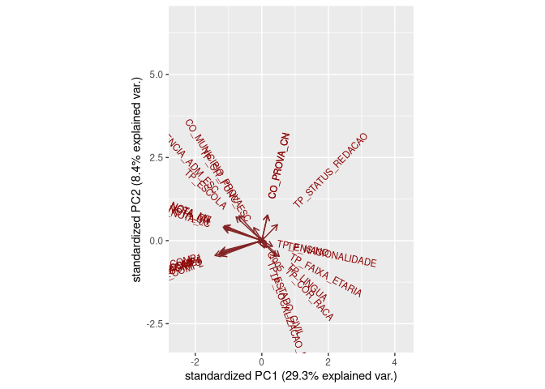

```r
ggbiplot(pca, alpha=0)
```

### Análise dos resultados

```r
# cmdscale(dist(enem.df_pca), eig=TRUE, k=2)

# Error: cannot allocate vector of size 149.0 Gb (!!!)
```

# Visualização dos dados

**Questão 1** Qual é situação da presença na prova no contexto da pergunta Q024: Na sua residência tem computador?

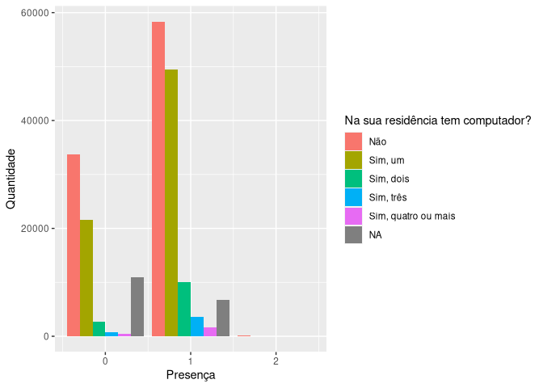

```r
conj_1 <- enem.df

ggplot(conj_1) +
  geom_histogram(aes(x= TP_PRESENCA_CH, fill=Q024), position = position_dodge(), stat="count") +
   labs(x = "Presença", y = "Quantidade", fill = 'Na sua residência tem computador?')+
  scale_fill_discrete(labels=c('Não','Sim, um','Sim, dois','Sim, três','Sim, quatro ou mais'))
```

**Questão 2:** Qual a média de desempenho na prova por cor/raça declarada?  
Vamos utilizar um boxplot para analisar, além da média, a distribuição de pontuações para cada cor/raça declarada no momento da inscrição da prova. Para isso, também vamos criar uma função para calcular a média das 4 provas e redação, o que significa que apenas poderemos usar os participantes que compareceram à prova.

[figure not shown]

```r
# filtro pelos candidatos presentes na prova
# e seleção apenas dos atributos de interesse
notas_cor_raca <- filter(enem.df, TP_PRESENCA_CH == 1 & TP_STATUS_REDACAO == 1) %>%
                  select(NU_NOTA_CN, NU_NOTA_CH, NU_NOTA_LC,
                    NU_NOTA_MT, NU_NOTA_REDACAO, TP_COR_RACA)

# rotulando dados categóricos
notas_cor_raca$TP_COR_RACA <- factor(notas_cor_raca$TP_COR_RACA,
                                levels = c(0,1,2,3,4,5,6),
                                labels=c('Não declarado',
                                'Branca','Preta',
                                'Parda','Amarela',
                                'Indígena',
                                'Não dispõe da informação'))

# função de média simples para a prova
enem_mean <- function(CN, CH, LC, MT, RD) {
  (CN+CH+LC+MT+RD)/5
}

# conjunto contendo apenas média e raça
dados_PLOT2 <- summarise(notas_cor_raca, "Cor/Raça" = TP_COR_RACA,
                      "Nota média" = enem_mean(NU_NOTA_CN,
                      NU_NOTA_CH, NU_NOTA_LC, NU_NOTA_MT, NU_NOTA_REDACAO))

media_geral <- mean(dados_PLOT2$`Nota média`)

# boxplot com uma linha na direção da média geral da prova
ggplot(data = dados_PLOT2) +
  geom_boxplot(outlier.size=.7, mapping = aes(x = `Cor/Raça`, y = `Nota média`)) +
  geom_hline(yintercept = media_geral, color = "blue")
```

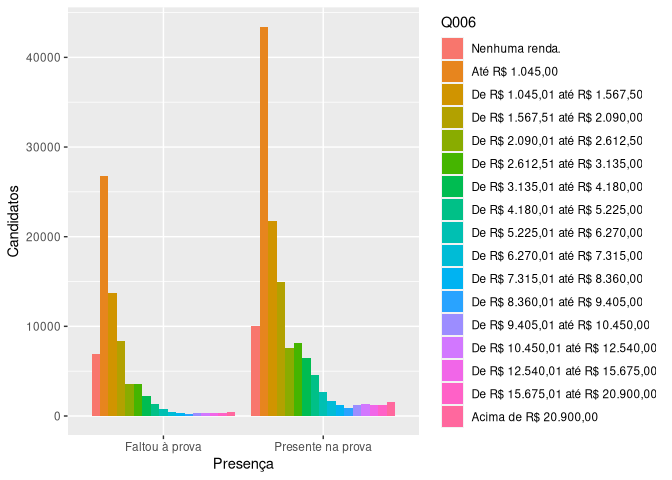

```r
# removendo candidatos eliminados da prova para melhorar a visualização
presenca_renda <- filter(enem.df, TP_PRESENCA_CH < 2) %>%
                  select(TP_PRESENCA_CH, Q006)

# rotulando dados categóricos
presenca_renda$TP_PRESENCA_CN <- factor(presenca_renda$TP_PRESENCA_CH, levels = c(0,1),
                                    labels=c('Faltou à prova',
                                             'Presente na prova'))

# rotulando dados categóricos
presenca_renda$Q006 <- factor(presenca_renda$Q006,levels =  c('A','B','C','D','E','F','G','H','I','J','K','L','M','N','O','P','Q'),
                         labels=c('Nenhuma renda.',
                                  'Até R$ 1.045,00',
                                  'De R$ 1.045,01 até R$ 1.567,50',
                                  'De R$ 1.567,51 até R$ 2.090,00',
                                  'De R$ 2.090,01 até R$ 2.612,50',
                                  'De R$ 2.612,51 até R$ 3.135,00',
                                  'De R$ 3.135,01 até R$ 4.180,00',
                                  'De R$ 4.180,01 até R$ 5.225,00',
                                  'De R$ 5.225,01 até R$ 6.270,00',
                                  'De R$ 6.270,01 até R$ 7.315,00',
                                  'De R$ 7.315,01 até R$ 8.360,00',
                                  'De R$ 8.360,01 até R$ 9.405,00',
                                  'De R$ 9.405,01 até R$ 10.450,00',
                                  'De R$ 10.450,01 até R$ 12.540,00',
                                  'De R$ 12.540,01 até R$ 15.675,00',
                                  'De R$ 15.675,01 até R$ 20.900,00',
                                  'Acima de R$ 20.900,00'))

# plot de histograma separando dados por renda familiar
ggplot(presenca_renda) +
  geom_histogram(aes(x= TP_PRESENCA_CN, fill=Q006), position = position_dodge(), stat="count") +
  labs(x = "Presença", y = "Candidatos")
```

**Questão 4:** Qual o desempenho médio das notas de redação por estado? Para responder essa questão, vamos precisar dos dados de nota de redação e estado da aplicação da prova. Vamos agrupar os valores por estado e utilizar a função `mean()` para calcular a média por estado, através do `summarise()`.

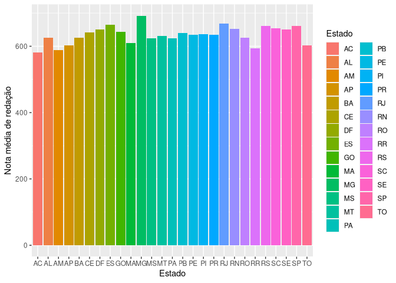

```r
# selecionando apenas redações válidas
redacao_estado <- filter(enem.df, TP_STATUS_REDACAO == 1) %>%
                  select(NU_NOTA_REDACAO, SG_UF_PROVA) %>%
                  group_by(SG_UF_PROVA)

# cálculo de nota média por estado
redacao_estado <- summarise(redacao_estado, Media = mean(NU_NOTA_REDACAO))


ggplot(redacao_estado) +
  geom_bar(stat="identity",
           mapping = aes(x=SG_UF_PROVA, y=Media, fill=SG_UF_PROVA)) +
  labs(x = "Estado", y = "Nota média de redação", fill = "Estado")
```

# Visualização de dados em forma de hierarquia

A visualização de dados em forma de hieraquia escolhida foi representar a quantidade de pessoas que faltaram na prova por município e estado.

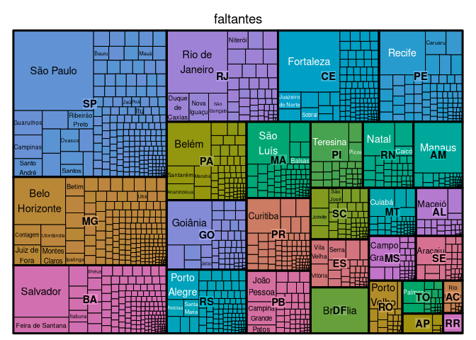

```r
conj_hie <- enem.df %>%
  filter(TP_PRESENCA_CH == 0) %>%
  group_by(SG_UF_PROVA, NO_MUNICIPIO_PROVA  ) %>%
  summarise(faltantes= n())
treemap(conj_hie,
        index=c("SG_UF_PROVA", "NO_MUNICIPIO_PROVA"),
        vSize="faltantes"
        )
```

# Referências

- https://rstudio-pubs-static.s3.amazonaws.com/558925_38b86f0530c9480fad4d029a4e4aea68.html#calculating-cramers-v-in-r
- https://statsandr.com/blog/outliers-detection-in-r